# Mainen & Sejnowski, 1995

Celà prouve aussi que l'on a "oublié" d'inclure un bruit intrinsèque à la dynamique du neurone:

```python
def leaky_IF(time=time, inp=I, tau=30, v0=-65, R=0.11,
                Vthreshold =-53, Vreset = -80, Vspike=30,
                VRest=-70, b=100, seed=None):
    np.random.seed(seed)
    V = np.ones_like(time)*v0
    dt = time[1]
    for t in range(len(time)-1):
        n=np.random.randn()
        dV = dt * (-(V[t] - VRest) + R*(inp[t]+b*n))/tau
        V[t+1] = V[t] + dV

        if V[t]>Vthreshold:
            V[t+1]= Vspike
        if V[t] == Vspike:
            V[t+1]=Vreset

    return V
```

Plusieurs essais montrent qu'avec un créneau les temps des spikes perdent leur reproducibilité, comme sur la figure:

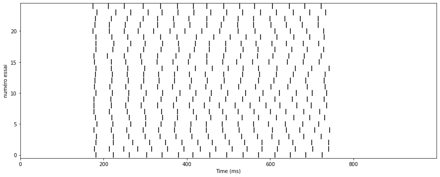

```python
n_trials = 25
V1 = np.zeros((n_trials,len(time)))

for i in range(n_trials):
    V1[i, :] = leaky_IF(time, Bruit(I_n=0, I_0=250))


fig, ax = plt.subplots(1, 1, figsize=(fig_width, fig_width/phi))
ax.eventplot([dt*np.where(V1.T[:, i] == 30)[0] for i in range(0, n_trials)],
              colors='black', lineoffsets=1, linelengths=0.9);
ax.set_ylabel('numéro essai')
ax.set_xlabel('Time (ms)')
ax.set_xlim(time.min(), time.max())
ax.set_ylim(-.5, n_trials-.5);
```

QUESTION : régler $I_0$ et $I_n$ pour obtenir un nombre qualitativement similaire de spikes en sortie du neurone. Pour celà, essayer de controler le nombre de spikes :

```
I_n = 700.0
number of spikes per trial : [10  9  9  9 10  9 10  9 10  9  9  9  9  9  9  9 10 10  9 10  9 10  9  8
 10]
```

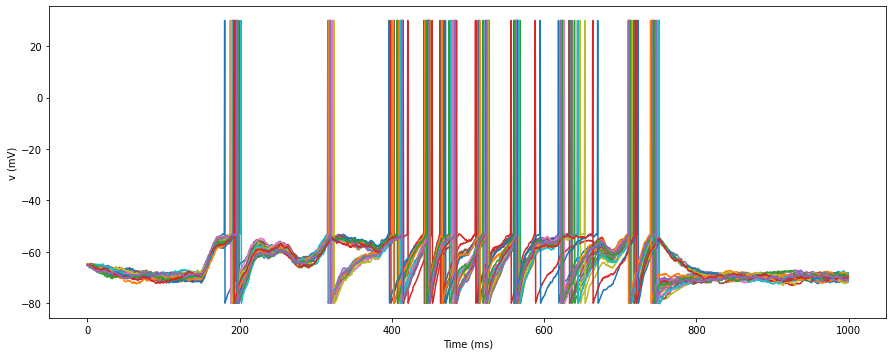

```
I_n = 850.0
number of spikes per trial : [11 11 10  9 10 11 10 10 10  9 10 10 11 10  9 10 10 11 11 10 11 10 10 11
 11]
```

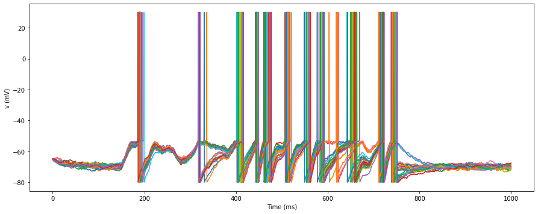

```
I_n = 1000.0
number of spikes per trial : [12 12 11 11 11 11 12 12 12 11 11 11 11 11 11 11 11 11 10 12 11 11 12 12
 10]
```

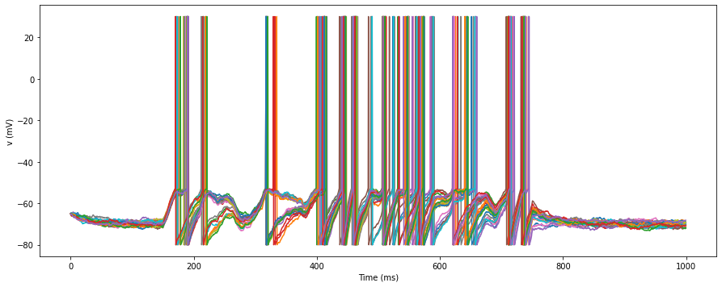

```
I_n = 1150.0
number of spikes per trial : [13 12 12 12 11 12 12 13 13 12 12 11 12 12 11 12 13 13 11 12 12 12 12 12
 11]
```

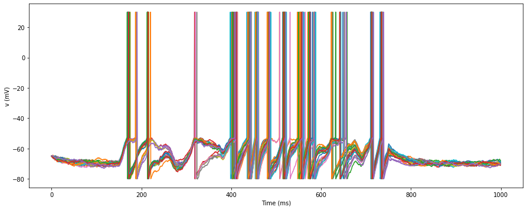

```
I_n = 1300.0
number of spikes per trial : [13 12 13 13 13 12 12 13 12 12 14 13 14 13 12 13 12 13 13 13 13 12 13 12
 12]
```

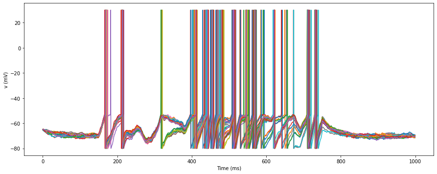

```python
for rho in np.linspace(0.7, 1.3, 5):
    I_n_ = rho*1000
    print('I_n =', I_n_)
    VA = np.zeros((n_trials,len(time)))

    for i in range(n_trials):
        VA[i, :] = leaky_IF(time, Bruit(I_n=I_n_, I_0=150))

    print('number of spikes per trial :', (VA>0).sum(axis=1))
    fig, ax = plt.subplots(1, 1, figsize=(fig_width, fig_width/phi))
    ax.plot(time, VA.T)
    ax.set_xlabel('Time (ms)')
    ax.set_ylabel('v (mV)');
    plt.show()
```

QUESTION : voir l'influence de $I_0$ sur le comportement

```
rho= 0.7
number of spikes per trial : [8 8 8 7 8 8 7 7 8 8 8 8 8 7 8 8 8 7 8 8 7 7 8 8 8]
```

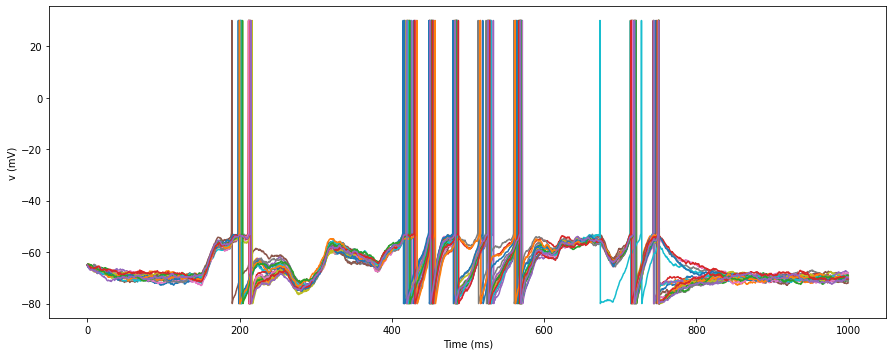

```
rho= 0.85
number of spikes per trial : [ 9  9  9  9 10 10  9  9  9  9  9  9  9  9  9 10  9 11  9  9  9 10 10  9
  9]
```

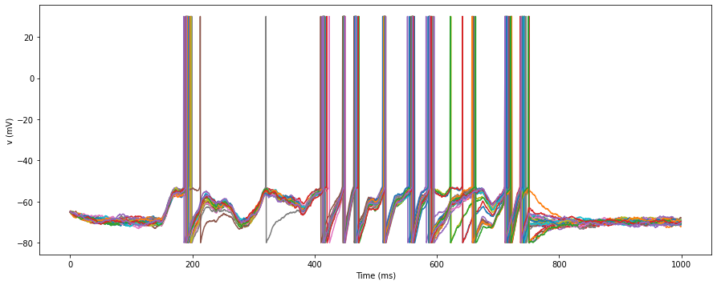

```
rho= 1.0
number of spikes per trial : [10 11 12 11 12 11 11 11 10 12 11 11 11 11 11 12 11 11 13 11 11 10 11 10
 11]
```

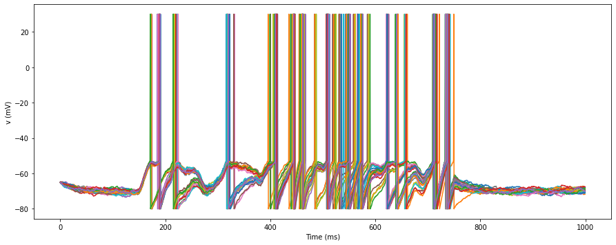

```
rho= 1.15
number of spikes per trial : [13 13 14 13 13 13 13 14 13 13 13 14 13 14 12 13 13 13 13 13 14 12 13 13
 13]
```

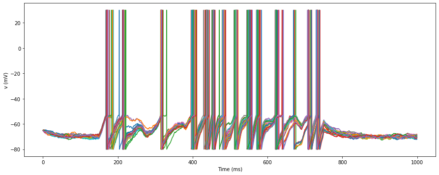

```
rho= 1.3
number of spikes per trial : [15 15 15 14 15 15 15 15 15 15 15 15 15 15 14 15 15 14 15 14 15 14 14 14
 14]
```

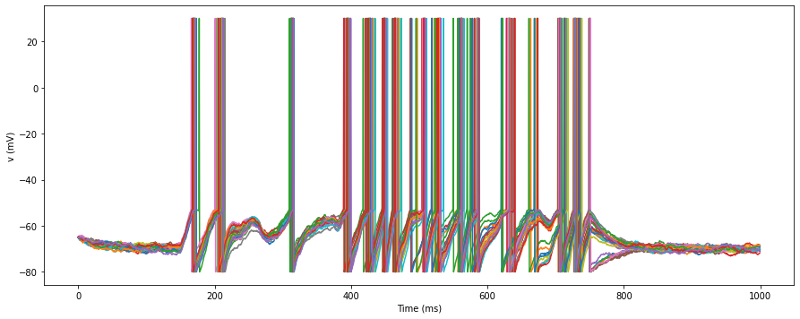

```python
for rho in np.linspace(0.7, 1.3, 5):
    print('rho=', rho)
    VA = np.zeros((n_trials,len(time)))

    for i in range(n_trials):
        VA[i, :] = leaky_IF(time, Bruit(I_n=1000, I_0=rho*150))

    print('number of spikes per trial :', (VA>0).sum(axis=1))
    fig, ax = plt.subplots(1, 1, figsize=(fig_width, fig_width/phi))
    ax.plot(time, VA.T)
    ax.set_xlabel('Time (ms)')
    ax.set_ylabel('v (mV)');
    plt.show()
```

QUESTION : voir l'influence de $I_0$ sur le comportement, *quand le bruit est nul* :

```
I_0_= 225.0
number of spikes per trial : [13 13 13 13 13 13 13 13 13 13 13 13 13 14 13 13 13 13 13 12 13 13 13 13
 13]
```

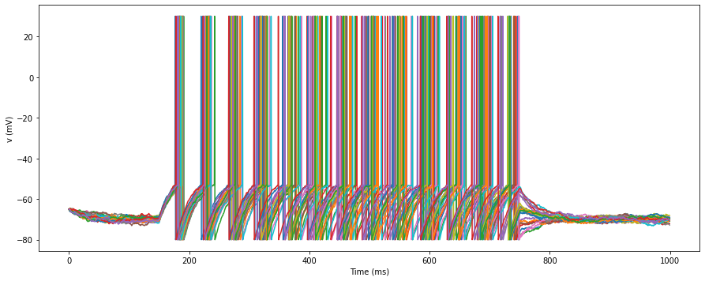

```
I_0_= 237.50000000000003
number of spikes per trial : [14 14 14 14 14 14 14 14 14 14 14 14 14 14 14 14 14 14 14 14 14 14 14 15
 14]
```

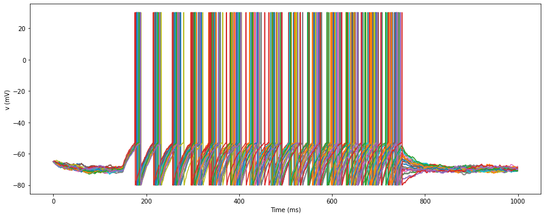

```
I_0_= 250.0
number of spikes per trial : [15 15 15 15 15 15 15 15 15 15 15 16 15 15 15 15 15 15 15 15 15 15 15 15
 15]
```

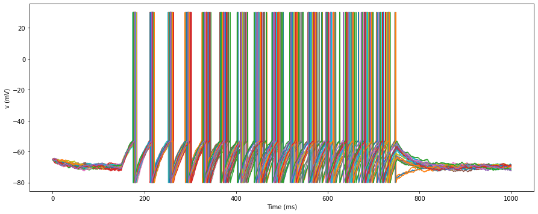

```
I_0_= 262.5
number of spikes per trial : [17 16 16 16 16 16 17 16 16 16 16 17 16 16 16 16 16 16 16 16 16 16 16 16
 16]
```

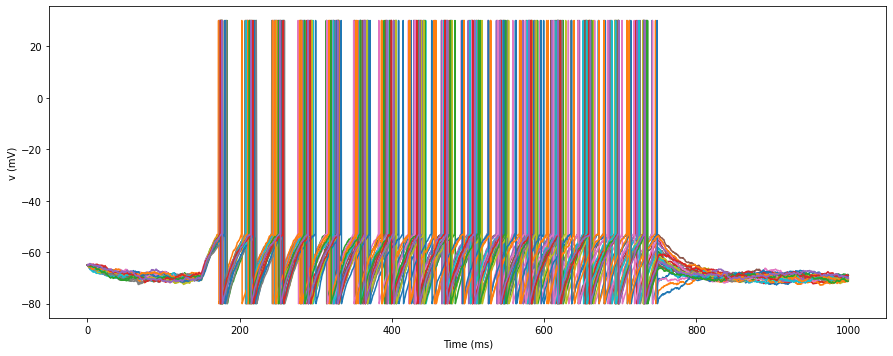

```
I_0_= 275.0
number of spikes per trial : [16 17 17 18 17 17 17 17 17 17 17 17 17 17 17 17 17 17 17 17 18 17 18 17
 17]
```

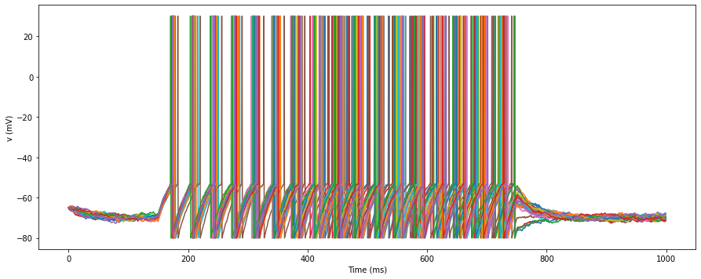

```python
for rho in np.linspace(0.9, 1.1, 5):
    I_0_ = rho*250
    print('I_0_=', I_0_)
    VA = np.zeros((n_trials,len(time)))

    for i in range(n_trials):
        VA[i, :] = leaky_IF(time, Bruit(I_n=0, I_0=I_0_))

    print('number of spikes per trial :', (VA>0).sum(axis=1))
    fig, ax = plt.subplots(1, 1, figsize=(fig_width, fig_width/phi))
    ax.plot(time, VA.T)
    ax.set_xlabel('Time (ms)')
    ax.set_ylabel('v (mV)');
    plt.show()
```

QUESTION: reproduire le panneau A: quand le bruit est nul, les traces des neurones ne sont pas reproductibles:

```
number of spikes per trial : [15 15 15 15 15 14 15 15 15 15 15 15 15 15 15 15 15 15 16 15 15 15 15 15
 15]
```

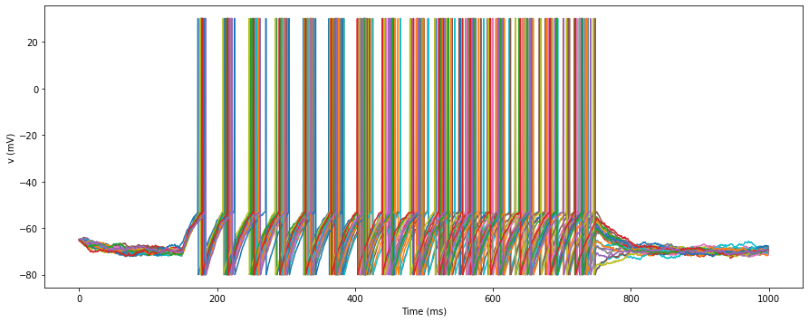

```python
seed = 2020
VA = np.zeros((n_trials,len(time)))
b_A = Bruit(I_n=0, I_0=250, seed=seed)

for i in range(n_trials):
    VA[i, :] = leaky_IF(time, b_A)

print('number of spikes per trial :', (VA>0).sum(axis=1))
fig, ax = plt.subplots(1, 1, figsize=(fig_width, fig_width/phi))
ax.plot(time, VA.T)
ax.set_xlabel('Time (ms)')
ax.set_ylabel('v (mV)');
```

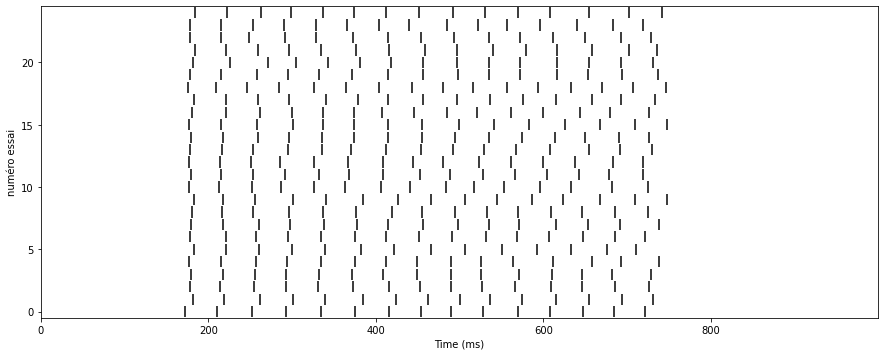

```python
fig, ax = plt.subplots(1, 1, figsize=(fig_width, fig_width/phi))
ax.eventplot([dt*np.where(VA.T[:, i] == 30)[0] for i in range(0, n_trials)],
              colors='black', lineoffsets=1, linelengths=0.9);
ax.set_ylabel('numéro essai')
ax.set_xlabel('Time (ms)')
ax.set_xlim(time.min(), time.max())
ax.set_ylim(-.5, n_trials-.5);
```

On reproduit le panneau B: avec un bruit gelé, les traces des neurones sont reproductibles, même quand le neurone possède un bruit intrinsèque:

```
number of spikes per trial : [11 10 10 10 10 11 11 11 11 11 11 11 10 11 11 11 11 10 10 11 11 10 10 11
 10]
```

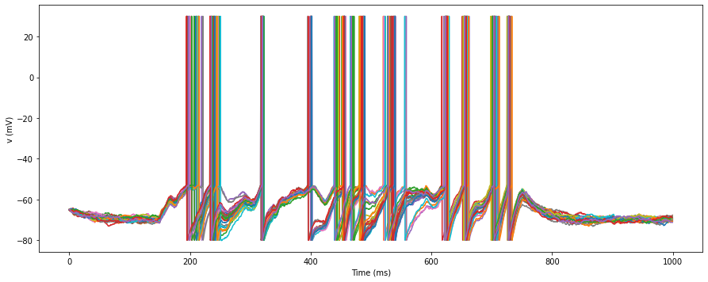

```python
VB = np.zeros((n_trials, len(time)))
b_B = Bruit(I_n=1000, I_0=200, seed=seed)
for i in range(n_trials):
    VB[i, :] = leaky_IF(time, b_B)

print('number of spikes per trial :', (VB>0).sum(axis=1))
fig, ax = plt.subplots(1, 1, figsize=(fig_width, fig_width/phi))
ax.plot(time, VB.T)
ax.set_xlabel('Time (ms)')
ax.set_ylabel('v (mV)');
```

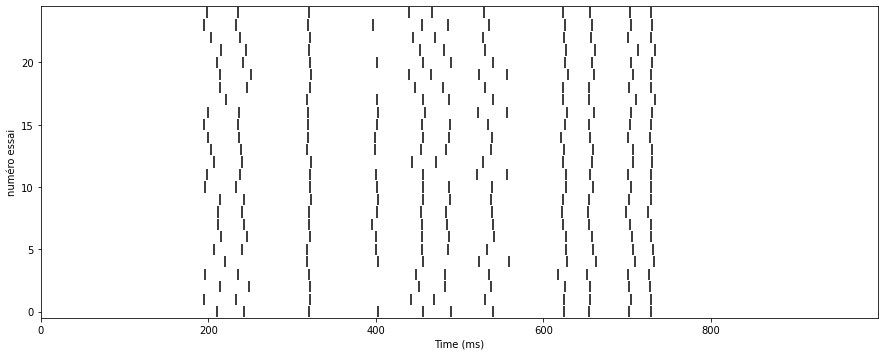

```python
fig, ax = plt.subplots(1, 1, figsize=(fig_width, fig_width/phi))
ax.eventplot([dt*np.where(VB.T[:, i] == 30)[0] for i in range(0, n_trials)],
              colors='black', lineoffsets=1, linelengths=0.9);
ax.set_ylabel('numéro essai')
ax.set_xlabel('Time (ms)')
ax.set_xlim(time.min(), time.max())
ax.set_ylim(-.5, n_trials-.5);
```

Pour résumer:

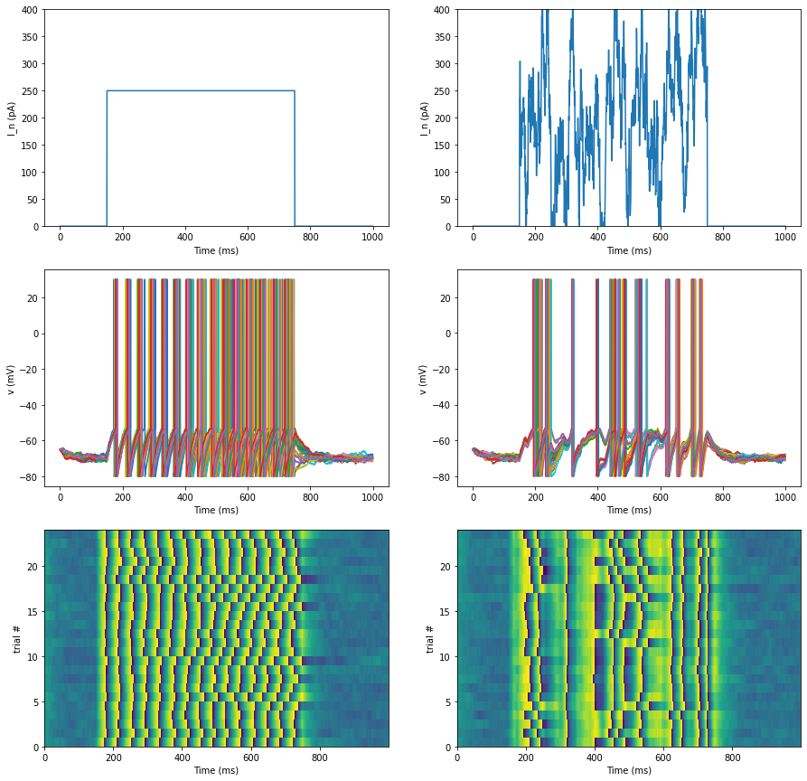

```python
fig, axs = plt.subplots(3, 2, figsize=(fig_width, fig_width))

axs[0][0].plot(time, b_A)
axs[0][1].plot(time, b_B)
axs[1][0].plot(time, VA.T)
axs[1][1].plot(time, VB.T)
axs[2][0].pcolor(time, range(n_trials), VA, vmax=Vthreshold)
axs[2][1].pcolor(time, range(n_trials), VB, vmax=Vthreshold)
for ax in axs.ravel():
    ax.set_xlabel('Time (ms)')
    ax.set_ylabel('v (mV)');
axs[2][0].set_ylabel('trial #');
axs[2][1].set_ylabel('trial #');
for i in range(2):
    axs[0][i].set_ylabel('I_n (pA)')
    axs[0][i].set_ylim(0, 400);
```

QUESTION: conclure rapidement: à quel point a-t-on expliqué le phénomène? quelle est la conclusion sur la préférence des neurones à des signaux dynamiques?

REPONSE: On a expliqué ce phénomène en faisant varier la fluctuation du courant, notamment en adaptant la fréquence de décharge des spikes. Les modèles de décharge sont reproductibles et sont un phénomène robuste en présence de fluctuations de stimulus. Quand le bruit est nul les traces des neurones ne sont pas reproductibles, par contre elles le sont avec "un bruit gelé" et cela même avec un bruit intrinsèque.

Cela nous a permis de mettre en évidence que si le neurone est stimulé avec un courant fluctuant, il émet des trains de PA de façon plus fiable et temporellement précise que si l’on utilise un stimulus plat. De plus, les nombreuses modifications que nous avons pu être amenés à faire sur les paramètres `I_n` et `I_0` nous démontrent l’importance des paramètres du bruit dans la genèse des PA. Les neurones montre une préférence pour les signaux bruités, dynamiques, qui permet donc le reflet d'une transmisson d'information fiable et précise. Ainsi, pour conclure simplement, on peut suggérer que les neurones ont une préférence pour les signaux dynamiques (fluctuants), ce qui correspond à la réalité biologique de la variabilité des entrées synaptiques qu’ils doivent intégrer pour créer des trains de PA discrets et de timing stable.

*Tentative d'application : parallèle entre bruit et traitement de l'information par le neurone*

Nous avons remarqué une ressemblance qualitative entre le bruit modélisé ici est similaire à un enregistrement LFP qui représenterais la *somme* de toutes les excitations ou inhibitions synaptiques dans une région donnée. En effet, les inputs enregistrés in vivo pour un neurone sont intrinsèquement bruités, le neurone serait donc moins adapté au traitement d'un signal continu non bruité. De cette manière nous pourrions ici relier `I_n` à un critère de *sommation spatiale* et `I_0` de *sommation temporelle*.